# RingdateR

David Reynolds, David Edge

February 6, 2020

## Introduction

RingdateR is designed to facilitate visual and statistical crossdating of tree ring and growth increment width series of both live- and dead-collected samples. RingdateR has a particular focus on facilitating the crossdating of dead-collected samples, with unknown antiquities, either against each other (i.e. pairwise analysis) or an existing absolutely dated chronology. As RingdateR is a crossdating application, it has not been designed for the construction of chronologies and as such does not contain facilities for performing regional curve standardisation or signal free detrending or more sophisticated tools for combining data sets into robust mean chronologies. The tools set out in RingdateR are designed to facilitate the evaluation of growth patterns in annually resolved archives to facilitate the dating of samples either relative to each other, or relative to an existing mean chronology.

Before using any of the RingdateR functions, you will need to install the package from the CRAN library.

You will also need to load the package.

```r
library(ringdater)
```

## Loading Undated Time Series

RingdateR is compatable with an array of file formats including: csv, txt (tab delimitted), MS Excel, pos (cooRecorder), and lps (ImagePro). Loading series of any format follows a similar procedure:

### Example data can be downloaded from a GitHub repository at the following URL:

https://github.com/davidjreynolds/ringdater.git

After unzipping the example data to a known location, you can proceed to load the data into R using various data loading functions.

### ImagePro (lps) files

```r
TND035 <- load_lps(path = "E:/ExampleData/TND035.lps", series = "TND035")
```

### CooRecorder (pos) files

```r
Carl2L <- load_pos(file_name = "Carl2L", file_path = "E:/ExampleData/Carlton2L.pos")
```

### Comma separated values (csv) files

```r
exampleData <- read.csv("E:/ExampleData/CaliGeoduck.csv", header = TRUE, stringsAsFactors = FALSE)
```

*The following example is based on the csv file data loaded above*

## Detrending ring width data

```r
detrendedData <- normalise(the.data = exampleData, detrending_select = 3, splinewindow = 7)
```

## Lead-lag analysis

```r
pairwiseData <- lead_lag_analysis(the_data = detrendedData, mode = 1, neg_lag = -20, pos_lag = 20, complete = FALSE, shiny = FALSE)
```

### Lead-lag results bar chart

Examine the lead-lag results betwen two samples as a bar chart

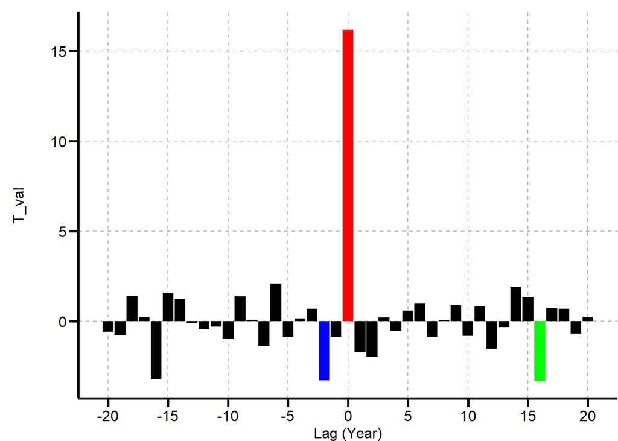

```r
lead_lag_bar(the_data = as.data.frame(pairwiseData[2]), sample_1 = colnames(detrendedData)[2],sample_2 = colnames(detrendedData)[3])
```

### Lead-lag results heatmap

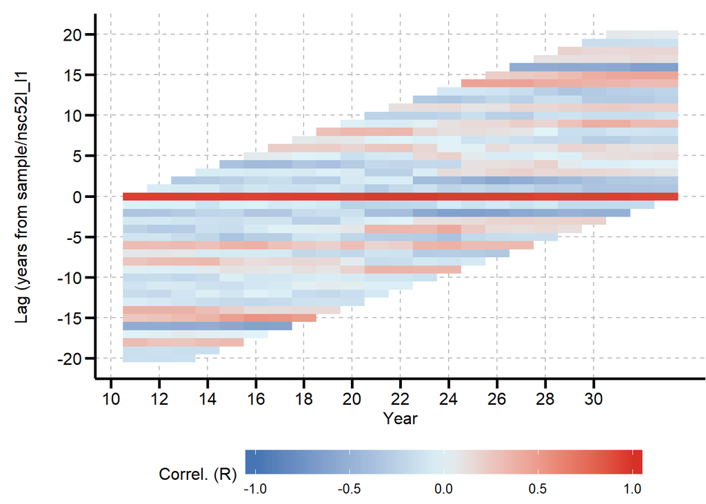

```r
heatmap_analysis(the_data = detrendedData, samp1 = 2, samp2 = 3, complete = FALSE)
```

## Check statistics

```r
filtered_data <- filter_crossdates(the_data = as.data.frame(pairwiseData[1]), r_val = 0.3, p_val = 0.05, overlap = 30, target = colnames(detrendedData)[2])
```

## Align and plot the data

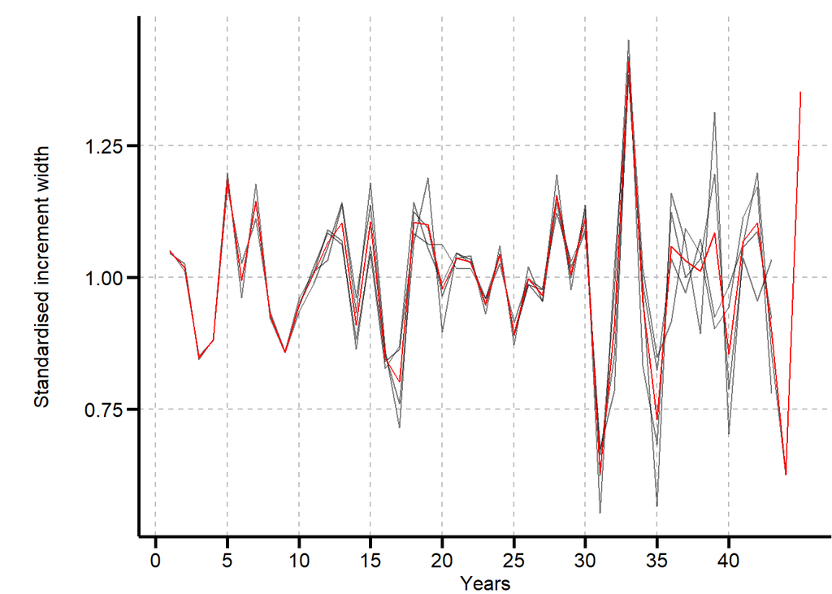

```r
aligned_data <- align_series(the_data = detrendedData, cross_dates = filtered_data, sel_target = colnames(detrendedData)[2])

plot_all_series(aligned_data)
```

# Evaluate the newly aligned data

Correlations between each sample and the arithemtic mean chronology with replacement

```r
correl_replace(aligned_data)
```

```
##      Series ID First Ring Last ring   R value      P value
## cor   sc52l_l1          1        43 0.8879136 2.066942e-15
## cor1  sc52l_l2          1        43 0.8589297 1.732761e-13
## cor2  sc55r_l1         10        43 0.8076851 7.768318e-09
## cor3  sc55r_l2         10        45 0.8719995 1.878431e-11
##      Overlap with chronology
## cor                       43
## cor1                      43
## cor2                      34
## cor3                      34
```